# Lab 3

Author

Jacky Wu

## Setup

```r
library(tidyverse)
```

```r
hiphop <- read_csv(here::here("supporting_artifacts" , "Datasets" , "hiphop.csv"))
```

## Problem 1

```r
nrow(hiphop)
```

```
[1] 10752
```

```r
ncol(hiphop)
```

```
[1] 38
```

*Your Comment: Where was this study conducted? How was the sample of participants selected? How many students were in the sample? How were the participants definitions coded?*

Looking at this dataset, there are 10752 observations and 38 variables. There are a lot of NA in the dataset, specifically for variables numOverallArtist and numPreferredArtist. The NA indicates that the artist don’t include the specific word in their songs. The study was conducted at the University of Minnesota. There are 168 participants and they were students who were enrolled in undergraduate linguistics, sociology, and music classes. The participants definitions were coded to a five-point Likert scale.

## Problem 3

*Your Comment: If this is a bad idea, what is a benefit of doing this?*

The variables SAAMEMove and blackWeekly had missing values replaced with the mean values of the respective variables. This would cause problems when we need to do analysis on these variables. An example would be if we would want to graph these variables. The graph would be skewed with these replaced values and won’t represent the true distribution of these variables. A benefit in doing this would be that we won’t have missing values. A lot of the times when data scientist explore a data set, it is a good practice to usually drop missing values if it doesn’t help with our observations.

## Problem 5

*Your Comment: I’d like to see a single output for the number of words, not a table*.

```r
hiphop %>%
  distinct(word) %>%
  nrow()
```

```
[1] 64
```

There are 64 AAE words that are studied in this dataset.

## Problem 6

*Your Comment: I Strongly recommend against nested functions, as they are difficult for people to understand what your code is doing. Having two lines is not less efficient and is more readable.*

```r
hiphop <- hiphop %>%
  mutate(ethnic = ifelse(ethnic == 'white', "white", "non-white"),
         ethnic = as.factor(ethnic))
```

## Problem 7

```r
distinct_hiphop <- hiphop %>%
  distinct(subj, .keep_all = TRUE)
distinct_hiphop %>%
  select(sex:ethnic) %>%
  summary()
```

```
     sex                 age              ethnic
 Length:168         Min.   :16.00   non-white: 33
 Class :character   1st Qu.:18.00   white    :135
 Mode  :character   Median :19.00
                    Mean   :20.02
                    3rd Qu.:20.00
                    Max.   :48.00
```

## Problem 8

*Your Comment: Plot titles are generally discouraged unless they include information not captured by either axis label*.

### Plots

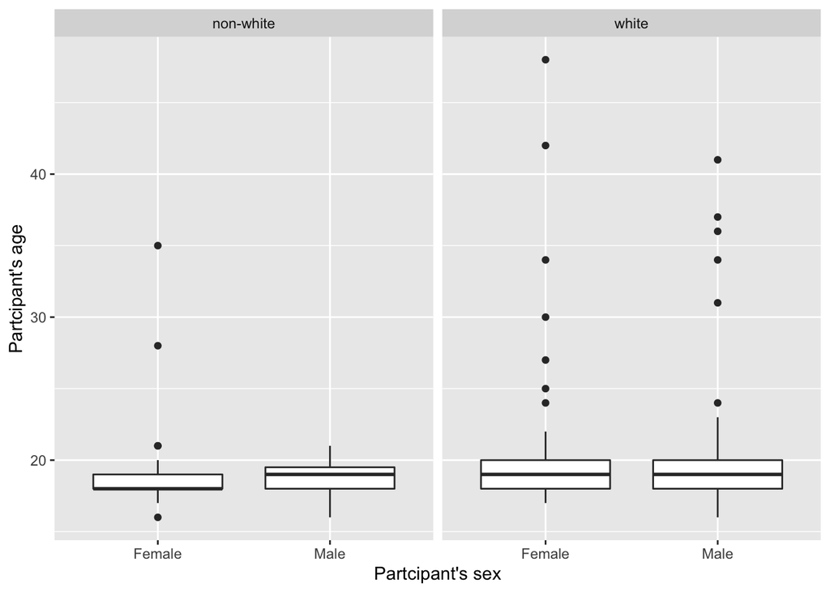

```r
ggplot(data = distinct_hiphop,
       mapping = aes(x = sex, y = age)) +
  geom_boxplot() +
  facet_wrap(~ethnic) +
  labs(x = "Partcipant's sex", y = "Partcipant's age")
```

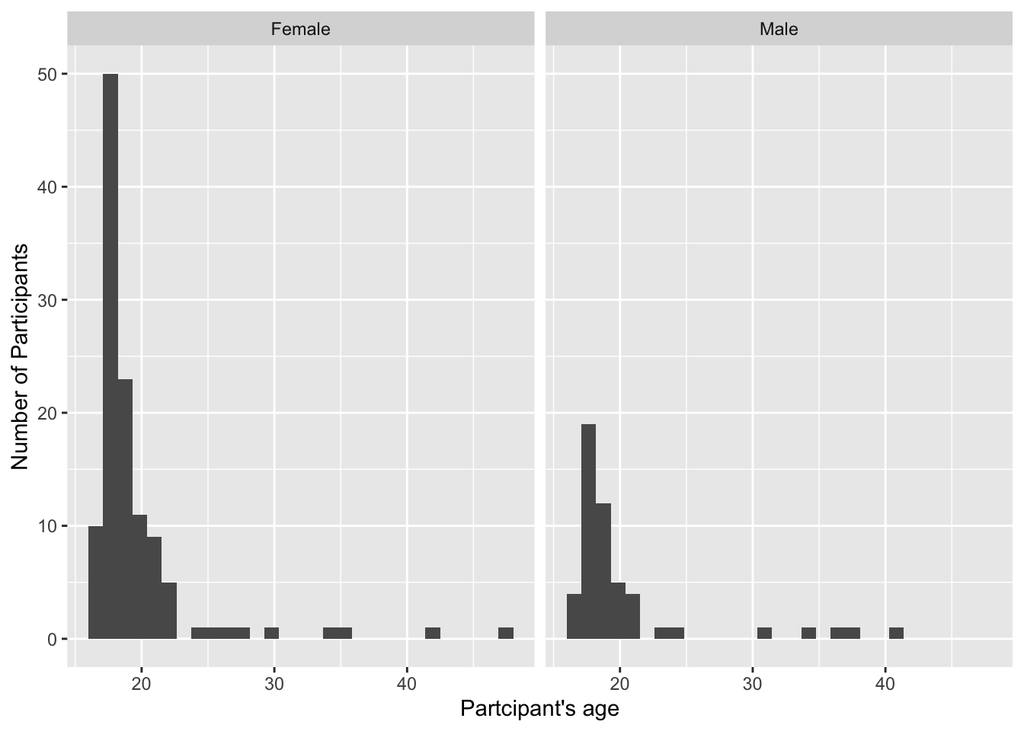

```r
ggplot(data = distinct_hiphop,
       mapping = aes(x = age)) +
  facet_wrap(~sex) +
  geom_histogram() +
  labs(x = "Partcipant's age", y = "Number of Participants")
```

### Familiar words

*Your Comment: Your code chucks should accomplish one task.*

```r
# a
below20 <- hiphop %>%
  filter(age < 20) %>%
  group_by(word) %>%
  summarise(across(familiarity, mean))
below20 %>%
  slice_max(familiarity)
```

```
# A tibble: 1 × 2
  word         familiarity
  <chr>              <dbl>
1 off the hook        4.42
```

```r
below20 %>%
  slice_min(familiarity)
```

```
# A tibble: 1 × 2
  word             familiarity
  <chr>                  <dbl>
1 catch the vapors        1.03
```

```r
# b
non_white_woman <- hiphop %>%
  filter(ethnic != 'white', sex == 'Female') %>%
  group_by(word) %>%
  summarise(across(familiarity, mean))
non_white_woman %>%
  slice_max(familiarity)
```

```
# A tibble: 1 × 2
  word    familiarity
  <chr>         <dbl>
1 feel me        4.19
```

```r
non_white_woman %>%
  slice_min(familiarity)
```

```
# A tibble: 4 × 2
  word              familiarity
  <chr>                   <dbl>
1 break someone out           1
2 dukey rope                  1
3 plex                        1
4 rollie                      1
```

```r
# c
white_man_above_30 <- hiphop %>%
  filter(ethnic == 'white', sex == 'Male', age > 30) %>%
  group_by(word) %>%
  summarise(across(familiarity, mean))
white_man_above_30  %>%
  slice_max(familiarity)
```

```
# A tibble: 1 × 2
  word   familiarity
  <chr>        <dbl>
1 May-00         4.2
```

```r
white_man_above_30  %>%
  slice_min(familiarity)
```

```
# A tibble: 25 × 2
   word              familiarity
   <chr>                   <dbl>
 1 ay yo trip                  1
 2 beezy                       1
 3 break someone out           1
 4 catch the vapors            1
 5 crossroads                  1
 6 crump                       1
 7 dap                         1
 8 dollar cab                  1
 9 domino                      1
10 duckets                     1
# … with 15 more rows
```

For people below the age of 20, the words ‘off the hook’ is the most familiar on average and the words ‘catch the vapors’ were the least familiar on average. For people that are non-white women, the words ‘feel me’ is the most familiar on average and the words ‘break someone out’, ‘dukey rope’, ‘plex’, and ‘rollie’ were the least familiar on average. For people that are white men above the age of 30, the words ‘May-00’ is the most familiar on average and there are 25 words that are the least familiar on average as shown in the code above.

### Study Subjects

*Your Comment: You have long lines of code. Please use new lines!*

```r
jb <- hiphop %>%
  filter(ethnic == 'white', sex == 'Male',
         city %in% 10000:60000,
         age %in% 17:23) %>%
  distinct(subj, .keep_all = TRUE)
jb %>%
  select(subj, bieber) %>%
  slice_max(bieber)
```

```
# A tibble: 1 × 2
  subj  bieber
  <chr>  <dbl>
1 p17        5
```

After filtering the data set to fit the description of Justin Bieber, I believe that subject 17 is the most likely candidate to be Justin Bieber. I used the variable to bieber to come to my conclusion. The variable beiber indicates the number of Justin Bieber songs the participants know up to five songs, 1 being zero songs and 6 being five songs. Subject 17 had a 5 in the variable beiber meaning the participant knows four songs. If the participant is Justin Beiber, he should know his own songs. Looking at the other participants in the filtered dataset, the next highest number for the variable is beiber, which indicates that the particant only knows one song from Justin Beiber. This highly indicates that all the other participants in the filtered data isn’t Justin Beiber since it would be ivery unlikely to only know one or none of the multiple songs you created. The only problem I have with this conclusion is that subject 17 got a 5 instead of a 6 for the variable beiber. If subject 17 is truly Justin Beiber, he should know five of his own songs.

# Reflection

When looking at a data set, it is good practice to look at where the experiment took place and how the participants were selected. It is also a good idea to understand the way a definition is coded in the data set. I also learned that plots don’t need titles unless they add more information that isn’t already captured by the axis labels. I also learned that it is better to have a code chunk complete a single task rather than have it complete multiple tasks as it can get crowded. I also don’t have to fit code into a single line and can separate them into different lines without having the code not run. Finally, I learned that it is sometimes better to not do multiple steps in a single line. I thought that having a single line of code doing multiple actions would be more efficient coding, but I got to remember that it is humans reading my code. It would be easier for the person reading my code if it doesn’t contain nested functions.